# Ecological Archives E095-258-metadata

*Ecological Archives* E095-258-D1

Stephen F. Matter, Nusha Keyghobadi, Jens Roland. 2014. Ten years of abundance data within a spatial population network of the alpine butterfly, *Parnassius smintheus*. *Ecology* 95:2985. http://dx.doi.org/10.1890/14-1054.1

Introduction

Metadata

Class I. Data set descriptors

**A. Data set title**: Ten years of abundance data within a spatial population network of the alpine butterfly, *Parnassius smintheus*

**B. Data set identification code**: PopulationAbunMark-Recap.csv; PopulationAbunTransect.csv; Dispersal.csv; Landscape.csv

**C. Data set description**

The data set consists of local population abundance and dispersal data for 17–21 populations from 1995–2004. Populations were censused between 1–11 times each year using either mark-release-recapture methods or by Pollard transect surveys. In all cases, abundance data are reported in units of abundance equivalent to or calculated by Craig's estimate. The observed number of immigrants and emigrants over the flight season are provided for populations in years in which mark-recapture was conducted. Landscape data including the area, latitude, longitude, and elevation of the center of the meadow in which each population resides is also provided.

**Abstract:** Spatial population networks (metapopulations sensu lato) have distinct properties from isolated populations. Within a population network, the abundance, persistence, and dynamics of local populations are affected by other populations within the network. Similarly, the abundance of local populations within the network has a strong effect on the dynamics and persistence of the entire network. In this data paper, we present 10 years (1995–2004) of local population abundance and seven years of dispersal data within a spatial population network consisting of 21 local populations of the Rocky Mountain Apollo butterfly, Parnassius smintheus. Populations were located within alpine meadows above treeline (≈ 2100 m) along Lusk (51.01°N, 114.97°W) and Jumpingpound Ridges (50.95°N, 114.91°W) in the front ranges of the Rocky Mountains in Alberta, Canada. Mark–recapture methods were used to monitor all populations in 1995 and 1996, and most populations in 1997 and from 2001–2004. For these years, abundance was estimated using Craig’s method. In other years, population size was estimated via Pollard transects and converted to a common estimate of abundance based on a statistical relationship between transect counts and Craig’s estimate. We present multiple estimates of abundance for most populations over the adult flight season each year, and the observed number of emigrants and immigrants over the flight season for populations in years where mark–recapture was conducted. These data should be useful in synthetic studies of factors affecting local population abundance within spatial population networks, landscape genetics, spatial population dynamics, and the persistence of spatial population networks.

**D. *Key words***: *colonization; density; dispersal; extinction; fragmentation; landscape; Lepidoptera; metapopulation; migration; patch; population dynamics; recolonization.*

Class II. Research origin descriptors

**A. Overall project description**

**Identity:** A compilation of spatial population abundance and dispersal data.

**Period of Study:** Population data were collected several times during each summer (adult flight season) between 1995 and 2004.

**Sources of funding:** The compilation of this data set was supported by Discovery and Operating grants from the Natural Sciences and Engineering Research Council of Canada to JR and a National Science Foundation grant to SFM (DEB-0326957).

**B. Research Motivation**

The initial motivation for this study was to examine how the configuration of habitat affects dispersal in spatial population networks. In particular, we were interested in how different types of habitat affect movement (Pither and Taylor 1998, Haddad 1999, Ricketts 2001). In our case we investigated how subalpine forest and unforested areas affect the movement of *P. smintheus* among its alpine meadow habitat (Roland et al. 2000, Matter et al. 2004) as well as its genetic structure (Keyghobadi et al. 1999, 2005). We were particularly motivated to use this system because ≈70% of unforested area had been lost to forest encroachment over the last 50 years (Roland et al. 2000). Thus, the system could potentially serve as a model for the effects of treeline encroachment on spatial population persistence and landscape genetics.

Following detailed studies in 1995 and 1996, we realized that there were surprisingly few long-term studies detailing local population abundance within spatial population networks, other than simple presence or absence estimates. Thus, maintaining these data would be valuable. With somewhat limited funding and personnel from 1997–2000, we continued to estimate abundance within the local populations primarily using less labor intensive transect surveys (Pollard 1977).

Estimates of what the abundance and the observed number of immigrants to surrounding populations would have been had P and Q not been "extinct" can be found by calculating the proportional reduction in connectivity resulting from the extinction, i.e., using the connectivity equation provided in Matter and Roland (2010) and assuming populations sizes in P and Q were at their nominal abundance (provided here) or zero.

**C. General Methodology**

*Natural history* - *Parnassius smintheus* Doubleday, 1847 is distributed throughout alpine and subalpine meadows in the Rocky Mountains from northern New Mexico to the Yukon and in the costal ranges of California and British Columbia (Guppy and Shepard 2001). There is one generation per year (Bird et al. 1995). Larvae emerge shortly after snowmelt and feed on several Sedum species throughout their range. At our site they feed primarily on *Sedum lanceolatum* and less often on *Rhodiola integrifolia*. Larvae (and adults) are aposomatically colored and are thought to sequester defensive cyanoglycosides from their host plants (Nishida and Rothschild 1995, but see Bjarnholdt et al. 2012). Adults emerge in mid-July at our study area and generally the flight season continues until the near the end of August (Matter et al. 2011). Adults feed on nectar from a wide variety yellow flowers (Matter et al. 2009). Mated and unmated females lay eggs singly, near, but not on host plants. The butterfly overwinters as a pharate larvae (first instar larvae within the egg) and winter weather conditions strongly affect the population dynamics of this species (Roland and Matter 2013).

Because of differing objectives and research foci, different methods have been used to estimate the abundance of *P. smintheus*. In some cases we used Pollard transects and in other cases we used mark–release recapture methods and also estimated dispersal. Regardless of the methods, we attempted to conduct sampling on days that were warm and sunny because the flight of *P*. *smintheus* is sensitive to light conditions (Ross et al. 2005), and using either method butterflies were primarily detected while flying. Due to the alpine setting, weather conditions can change quickly. Thus on several occasions sampling was not as complete or populations were not sampled as many times as desired.

*Mark–recapture -* Individually-based mark–recapture was conducted within all populations in 1995 and 1996, and in a subset of the 21 populations in 1997 and from 2001–2004. For mark–recapture surveys butterflies were captured using hand nets. Each newly captured butterfly was given a unique three letter code on the underside of both hind wings using a permanent felt tipped marker (Sharpie Ultra Fine Point, Sanford Corp.). For all captures we recorded the butterfly's ID, the time and date of capture, whether the butterfly was newly captured or was a recapture, the meadow the butterfly was captured in and location based on X, Y coordinates derived from aerial photographs. We have estimated that these coordinates are accurate to about 10 m (Roland et al. 2000). *Parnassius smintheus* is sexually dimorphic. Thus, we also record the sex of the butterfly and, if female, whether she has mated or not based on the presence/absence of a sphragis which males secrete during mating to prevent females from remating (Calabrese et al. 2008). The presence of a sphragis is a definitive indication of mating; however, the lack of one does not necessarily confirm a virgin because a small percentage of females lose their sphragis over time (Matter et al. 2005). For this and other reasons we also age butterflies based on wing wear. Butterfly age was scored progressively as "new", "old", or "tattered" based on wing wear. The wings of newly emerged *Parnassius smintheus* are yellowy and soft to the touch. The dorsal surface of the wings fade to white and become more brittle with age, flight, and exposure to the sun. Butterflies with such wings were scored as "old." With increasing time and flight wings develop tears along the edges becoming tattered with frayed wing margins. We also recorded other incidental data such as if a butterfly was nectaring, the species of flower it was using, if it was mating and with whom, and if there was evidence of attempted bird predation. We also indicated such if a butterfly was sampled for genetic analysis by removing a small piece of wing tissue (Keyghobadi et al. 1999), which has little effect on survivorship or dispersal (Roland et al. 2000, Crawford et al. 2013). Additional data not used in estimating dispersal are not presented here, but can be requested by contacting the authors.

To estimate population size from mark–recapture censuses we used Craig's method, a continuous time, closed, capture-recapture model (Craig 1953, Southwood 1994). This method takes advantage of the fact that an individual butterfly can be captured multiple times during a census and does not require multiple census periods to arrive at a population estimate. In broad terms, the statistical distribution of the number of butterflies captured once, twice, thrice, etc. is used, assuming butterflies are encountered randomly, to estimate the zero-term of the Poisson distribution (number of butterflies never captured) and the estimate is added to the number of butterflies actually captured to arrive at a population estimate. Operationally, a population estimate is found by solving the maximum likelihood estimator developed by Craig (1953):

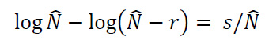

with

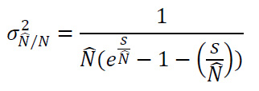

where *r* is the number of individual butterflies captured, *s* is the total number of captures, and is the estimate of population size. We estimated population size by solving the first equation using the "Solve" function in Mathematica 8.0 (Wolfram). Error of the estimate was calculated as the standard deviation, i.e., the square root of the second equation.

This method generally performs well. Wilson and Anderson (1995) showed that the model is comparable to discrete time models and Matter and Roland (2004) showed that it actually outperforms discrete time models when estimating abundance in this system. We attempted to recapture until about 75% of captures had been recaptured during a given census which should produce estimates with low error (Craig 1953); however, this was not always possible due to changing weather conditions.

*Transect surveys* - Transect surveys were conducted in several populations in 1997, and during 2001–2003; they were conducted in all populations in 1998–2000. From one to 5 observers were used per estimate. Each observer walked at a slow, constant pace (≈ one step per second) down the middle of each meadow and around the periphery at a 10m distance from the border. Each observer recorded the number of *P. smintheus* observed within a 10-m radius semicircle in front of them. When multiple observers were used they either used a different starting point or waited 10 min. from the prior observer before beginning a survey following the same route.

Transect surveys are perhaps the simplest population estimation technique. The method assumes, if multiple observers or observations are involved, a consistent path or amount of time is used, and that observers have similar ability in identification (Pollard 1977, Thomas 1983). To assure this, all observers were trained and similar paths and pacing was used. Because male and female *P. smintheus* can be difficult for novice observers to distinguish at 10 m (Matter and Illerbrun, *unpublished*) we present only total counts. The estimate of population abundance (mean transect count) was calculated as the mean of the number of butterflies reported by each observer.

*Statistical conversions* -In 2001, transect surveys and mark–recapture were conducted simultaneously to estimate population abundance within 9 different populations on 18 occasions. We used the relationship between population size estimated by each method to arrive at a common estimate based on Craig's method (Matter et al. 2004).

Here, we convert population abundance estimated by transect surveys to abundance estimated by Craig's method using the regression equation:

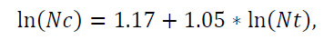

where *Nc* is the population estimate from Craig's method and *Nt* is the population estimate from a transect survey. Due to the natural log transformation, transect surveys of zero cannot be converted into an estimate and were assumed to be zero.

Mark–recapture surveys also occasionally produced no recaptures, making estimation via Craig's method impossible. In such cases, we used the statistical relationship between the number of individuals captured and population size estimated by Craig's method:

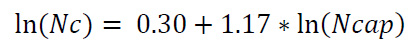

to estimate population size (Matter and Roland, 2004). Here, *Ncap* equals the number of individual butterflies captured. From 2001–2004, our experiment investigating the effects of population extinction for surrounding populations involved the removal of all butterflies from meadows P and Q. For these populations we also converted the number of butterflies captured (removed) to arrive at an estimate of population size.

*Dispersal* - The total observed number of emigrants from and immigrants to populations are provided for each year that mark-recapture was conducted for that population (1995–1997; 2001–2004). We considered any movement between populations, including those occurring within a census period as a dispersal event. Note that the application of these data requires consideration of inherent biases; please see data limitations below.

*Landscape* - The area (ha) of each meadow in which a population resides was based on GPS data collected in 2003 (Trimble Pathfinder) and differentially corrected for populations along Jumpingpound Ridge using a base station at the University of Calgary's Biogeosciences Institute. Areas along Lusk Ridge (populations C, D, d, and E) were estimated from a 1993 aerial photo. The latitude, longitude (decimal degrees), and elevation (m) of the center of each meadow were taken from a 10-m scale Digital Elevation Model (DEM) produced in 2009.

**D. Data Limitations and Potential Enhancements**

Here we discuss limitations in the existing data set. Our estimates of population size based on Craig's estimate are dependent on meeting the assumptions of the model. Craig's estimate makes two assumptions which are both violated by our data to some degree. The first is that populations are closed during sampling and the second is that all individuals have the same probability of capture at all times. With regards to the first assumption, butterflies do leave and enter each population to some degree; however, the time it takes to sample a population is relatively short, at most 2 hrs for large populations, thus this problem should generally be minimal. The assumption of a closed population is most commonly violated for butterflies along the borders of contiguous meadows, e.g., meadows G and g. Here, butterflies do sometimes move between populations during a census. In these cases, individuals and captures were counted for each population, e.g., if a butterfly was captured in G and g on the same date, that individual would be present in both populations and the number of times it was captured in G would be added to the total in G and the number of times it was captured in g added to the total captures in g. In reference to the second point, like many butterflies, female *P. smintheus* have a lower capture rate than males. Surprisingly, estimating abundance using Craig's method with a geometric, rather than a Poisson distribution, which should account for heterogeneity in capture probability, generally results in a poorer fit (Matter et al. 2004). A second source of heterogeneity in capture probability results from the time that it takes to process captured butterflies. While a butterfly is in the net or being marked it is not available to be captured. We generally try to minimize handling time by catching and processing butterflies one at a time. However, at times, particularly when abundance is high, this is not practical and multiple butterflies are often caught and then processed. Wilson and Anderson (1995) showed that Craig's method is fairly robust to this type of capture heterogeneity, but it does introduce a negative bias.

In several cases the recapture rate was low. Here, we provide an estimate of population size based on Craig's method, but include an indication in the notes that it is a poor estimate. In these cases we also provide an estimate based on the conversion from number of captures above.

Because of a variety of circumstances, e.g., weather, logistical constraints, accessibility, populations were not always sampled the same number of times throughout the flight season. In general, if populations were only sampled once or twice, either by mark-recapture or transect survey, we attempted to do so during the peak of adult abundance, usually around the beginning of August. For this reason, as a yearly index of population size, we use the maximal observed abundance (Roland and Matter 2013), rather than an estimate population size over the entire flight season.

A second limitation, or at least a consideration, is determining a local population extinction from these data. An observation of zero abundance throughout the flight season is necessary for a local extinction, but it does not necessarily mean that the population was extinct. For a population to be extinct, we use a more conservative metric, both the observation of no butterflies throughout the season and a lack of larval feeding scars on the host plant; however, this method only began in 2003.

The dispersal data also has important limitations and considerations. The data presented are the observed number of immigrants and emigrants for each population as sampled by mark-recapture. These data are subject to bias based on the number of times a population was sampled and the number of individuals marked in surrounding populations (Roland et al. 2000). In some years, all populations within the network were not sampled which should be considered when applying these data, e.g., in 2001 butterflies in populations I, J, K, and L were not marked or captured. The lack of mark-recapture in these populations will reduce the observed number of emigrants and immigrants for surrounding populations. Additionally, the experimental removal of populations P and Q (2001–2004) reduced observed immigration to populations L, M, N, O, R, and S. Equations showing the effects of the removals on immigration (and abundance) are provided in Matter and Roland (2010) and procedures for conversion are detailed at the end of the research motivation section. Immigrants to P and Q are provided during the experimental extinction. In all years of the experiment except 2001, all known immigrants were removed. In 2001, a small number of butterflies were also marked in P and Q and a few immigrants were not removed to examine the effectiveness of removals. Thus we also provide observed emigration from P & Q for 2001, but note that it is a highly biased estimate.

The landscape data is also subject to some error and limitations, in particular estimates of habitat area. Two-dimensional area was estimated for the four populations on Lusk Ridge from a 1993 aerial photograph. Similarly, two-dimensional area was calculated from GPS data collected in 2003. Two-dimensional area does not equal the total surface area available for butterflies. We also attempted to delineate known butterfly habitat, but in some cases this was not possible for photographs or was inaccessible for GPS, e.g. sheer cliffs. In these cases we estimated the areas in which sampled populations.

Class III. Data set status and accessibility

**A. Status**

**Latest update:** May 2014

**Latest Archive date:** May 2014

**Data verification:** Data is mostly from unpublished sources. We provide basic data from which abundances were calculated to allow independent verification.

**B. Accessibility**

**Contact person:** Stephen F. Matter, Department of Biological Sciences, University of Cincinnati, Cincinnati, OH 45220 USA, email: mattersf@uc.edu

**Copyright restrictions:** None.

**Proprietary restrictions:** Please cite this data paper when the data are used in publications. We also request that researchers and teachers inform us regarding how they are using the data.

**Costs:** None

**Acknowledgements -** Data collection was assisted by N. Ambrose, R. Cormier, S. Cotterill, D. Dennewitz, A. Fiskin, S. Fownes, M. Frantz, R. Hamilton, K. Kim, T. Lucas, E. Robinson, D. Roth, A. Ross, K. Sabourin, C. Schmidt, L. Scott, D. Sjostrom, K. Ward, A. Winship, and A. Winkelaar. We thank the University of Calgary's Biogeosciences Institute for logistical support. We also thank Husky Energy for allowing us to use their access road.

**Literature Cited**

Bird, C. D., G. J. Hilchie, N. G. Kondla, E. M. Pike, and F. A. H. Sperling. 1995. Alberta Butterflies. Provincial Museum of Alberta. Edmonton, Alberta, Canada.

Bjarnholt, N., M. Nakonieczny, A. Kędziorski, D. M. Debinski, S. F. Matter, C. E. Olsen, and M. Zagrobelny. 2012. Occurrence of sarmentosin and other hydroxynitrile glucosides *in Parnassius* butterflies and their food plants. Journal of Chemical Ecology 38:525–538.

Calabrese, J. M., L. Ries, S. F. Matter, J. N. Auckland, D. M. Debinski, J. Roland, and W. F. Fagan. 2008. Reproductive asynchrony in natural butterfly populations and its consequences for female matelessness. Journal of Animal Ecology 77:746–756.

Craig, C. C. 1953. On the utilization of marked specimens in estimating populations of flying insects. Biometrika 40:170–176.

Crawford, L. A., D. Koscinski, K. M. Watt, J. N. McNeil, and N. Keyghobadi. 2013. Mating success and oviposition of a butterfly are not affected by non-lethal tissue sampling. Journal of Insect Conservation 17:859–864.

Guppy, C. S., and J. H. Shepard. 2001. Butterflies of British Columbia. University of British Columbia Press, Vancouver, British Columbia, Canada.

Haddad, N. M. 1999. Corridor and distance effects on interpatch movements: a landscape experiment with butterflies. Ecological Applications 9:612–622.

Keyghobadi, N., J. Roland, and C. Strobeck. 1999. Influence of landscape on the population genetic structure of the alpine butterfly *Parnassius smintheus* (Papilionidae). Mol. Ecol. 8:1481–1495.

Keyghobadi, N., J. Roland, S. F. Matter, and C. Strobeck. 2005. Among- and within-patch components of genetic diversity respond at different rates to habitat fragmentation: an empirical demonstration. Proc. R. Soc. London B 272:553–560.

Matter, S. F., A. Doyle, K. Illerbrun, J. Wheeler, and J. Roland. 2011. An assessment of direct and indirect effects of climate change for populations of the Rocky Mountain Apollo butterfly (*Parnassius smintheus* Doubleday). Insect Science 18:385–392.

Matter, S. F., M. Ezzeddine, E. Duermit, J. Mashburn, R. Hamilton, T. Lucas, and J. Roland. 2009. Interactions between habitat quality and connectivity affect immigration but not abundance or population growth of the butterfly, *Parnassius smintheus*. Oikos 118:1461–1470.

Matter, S. F., B. Reed, K. Illerbrun, A. Doyle, S. McPike, and J. Roland. 2012. Young love? Mating of *Parnassius smintheus* Doubleday (Papillionidae). Journal of the Lepidopterists' Society 66:111–113.

Matter, S. F., J. Roland, A. Moilanen, and I. Hanski. 2004. Migration and survival of *Parnassius* *smintheus*: detecting effects of habitat for individual butterflies. Ecol. App. 14:1526–1534.

Matter, S. F. and J. Roland. 2004. Relationships among population estimation techniques: an examination for *Parnassius smintheus*. J. Lep. Soc. 58:189–195.

Matter, S. F., and J. Roland. 2010. Effects of experimental population extinction for the spatial population dynamics of the butterfly *Parnassius smintheus*. Oikos 119:1961–1969.

Nishida, R., and M. Rothschild. 1995. A cyanoglucoside stored by a Sedum-feeding Apollo butterfly, *Parnassius phoebus*. Experientia 51:267–269.

Pither, J., and P. D. Taylor. 1998. An experimental assessment of landscape connectivity. Oikos 83:166–174.

Pollard, E. 1977. A method for assessing changes in the abundance of butterflies. Biological Conservation 12:115–134.

Ricketts, T. H. 2001. The matrix matters: effective isolation in fragmented landscapes. American Naturalist 158: 87–99.

Roland, J., N. Keyghobadi, and S. Fownes. 2000. Alpine *Parnassius* butterfly dispersal: effects of landscape and population size. Ecology 81:1642–1653.

Roland, J., and S. F. Matter. 2007. Encroaching forests decouple alpine butterfly population dynamics. PNAS 104:13702–13704.

Roland, J., and S. F. Matter. 2013. Variability in winter climate and winter extremes reduces population growth of an alpine butterfly. Ecology 94:190–199.

Ross, J. A., S. F. Matter, and J. Roland. 2005. Edge avoidance and movement of the butterfly *Parnassius smintheus* in matrix and non-matrix habitat. Landscape Ecology 20:127–135.

Southwood, T. R. E. 1994. Ecological Methods, Second Edition. Chapman and Hall, London, UK.

Thomas, J. A. 1983. A quick method for estimating butterfly numbers during surveys. Biological Conservation 27:195–211.

Wilson, K. R., and D. R. Anderson. 1995. Continuous-time capture-recapture population estimation when capture probabilities vary over time. Environmental and Ecological Statistics 2:55–69.

[Back to E095-258]